# Projet Visualisation des Données

ROA SERRANO Walter - LIEPO Brice-Kevin

18/avril/2020

## I) INTRODUCTION

La visualisation de donnees designe la representation graphique d’informations et de donnees. Elle est aujourd’hui exploitee par de nombreuses entreprises qui gerent de vastes volumes de donnees issues notamment de base de donnees, de CRM ou encore de tableurs. Ces entreprises la privilegient desormais pour les raisons suivantes :

- Elle facilite la comprehension d’un grand jeu de donnees;
- Elle synthetisee les informations;
- Elle rend les donnees accessibles a un plus grand nombre de personnes. Elle est donc devenu indispensable pour analyser d’enormes quantite d’informations ou etudier de grand volumes de donnees et joue un role de plus en plus important dans les domaines scientifiques et techniques, dans l’administration, dans la finance, en marketing, dans le secteur des services ou dans le sport.

## II) OBJECTIFS DU PROJET

Ce projet, realise dans le cadre du cours de visualisation de donnees, consiste a :

- Enrichir nos connaisances en R;
- Utiliser differentes techniques de visualisation de donnees mise a notre disposition par R;
- Appliquer ces differentes techniques sur un jeu de donnees afin de faire une visualisation assez complete;
- Apprendre a faire le choix des graphes et des diagrammes les plus pertinentes;
- Comprendre, interpreter et analyser les differents graphes obtenus;
- Se familiariser avec l’utilisation des techniques de visualisation propres a R.

## III) PRESENTATION DES DONNEES

Le jeu de donnees utilise pour notre analyse, concernent le domaine du football. Il rassemble l’ensemble des observations sur plus de 17.588 footballeurs decrient par 53 variables. Ces differentes caracteristiques datent de 2017 et proviennent d’analyses de differents specialistes du domaine du football. Pour une meilleure lisibilite, nous n’allons afficher que les 4 premieres variables des 10 premiers individus de notre jeu de donnees :

```
## # A tibble: 10 x 4
##    Nom                Nationalite Club           Position
##    <chr>              <fct>       <fct>          <fct>
##  1 CRISTIANO RONALDO  PORTUGAL    REAL MADRID    AILIER
##  2 LIONEL MESSI       ARGENTINA   FC BARCELONA   AILIER
##  3 NEYMAR             BRAZIL      FC BARCELONA   AILIER
##  4 LUIS SUAREZ        URUGUAY     FC BARCELONA   ATTAQUANT
##  5 MANUEL NEUER       GERMANY     FC BAYERN      GARDIEN
##  6 DE GEA             SPAIN       MANCHESTER UTD GARDIEN
##  7 ROBERT LEWANDOWSKI POLAND      FC BAYERN      ATTAQUANT
##  8 GARETH BALE        WALES       REAL MADRID    AILIER
##  9 ZLATAN IBRAHIMOVIC SWEDEN      MANCHESTER UTD ATTAQUANT
## 10 THIBAUT COURTOIS   BELGIUM     CHELSEA        GARDIEN
```

Apres avoir affine nos donnees, elles contiennent maintenant 150 observations et 25 variables, toutes decrivant les caracteristiques propres a chacun des footballeurs.

```
## Classes 'tbl_df', 'tbl' and 'data.frame':    150 obs. of  25 variables:
##  $ Nom               : chr  "CRISTIANO RONALDO" "LIONEL MESSI" "NEYMAR" "LUIS SUAREZ" ...
##  $ Nationalite       : Factor w/ 34 levels "ALGERIA","ARGENTINA",..: 25 2 7 33 18 30 24 34 31 5 ...
##  $ Club              : Factor w/ 35 levels "1. FC KOLN","ARSENAL",..: 29 13 13 13 14 23 14 29 23 10 ...
##  $ Position          : Factor w/ 11 levels "AILIER","ATTAQUANT",..: 1 1 1 2 6 6 2 1 2 6 ...
##  $ Evaluation        : int  94 93 92 92 92 90 90 90 90 89 ...
##  $ Taille_en_cm      : int  185 170 174 182 193 193 185 183 195 199 ...
##  $ Poids_en_kg       : int  80 72 68 85 92 82 79 74 95 91 ...
##  $ Pied_Fort         : Factor w/ 2 levels "DROIT","GAUCHE": 1 2 1 1 1 1 1 2 1 2 ...
##  $ Age               : int  32 29 25 30 31 26 28 27 35 24 ...
##  $ Pied_Faible       : Factor w/ 5 levels "1","2","3","4",..: 4 4 5 4 4 3 4 3 4 3 ...
##  $ Dribbles          : int  92 96 95 88 39 22 86 88 88 18 ...
##  $ Defense           : int  25 22 26 37 10 15 28 52 27 15 ...
##  $ Attaque           : int  90 87 86 90 24 21 87 83 89 18 ...
##  $ Interception      : int  29 22 36 41 30 30 39 59 20 15 ...
##  $ Vision_du_Jeu     : int  85 90 80 84 70 68 78 79 83 44 ...
##  $ Centre            : int  84 77 75 77 15 17 62 87 76 14 ...
##  $ Passe             : int  80 87 78 73 57 31 74 83 80 31 ...
##  $ Rapidite          : int  91 89 91 82 59 56 80 94 71 49 ...
##  $ Endurance         : int  92 74 79 89 44 25 79 78 75 38 ...
##  $ Force             : int  80 59 49 76 83 64 84 80 93 70 ...
##  $ Equilibre         : int  63 95 82 60 35 43 79 65 41 45 ...
##  $ Agilite           : int  90 90 96 86 52 57 78 77 86 61 ...
##  $ Tete              : int  85 71 62 77 25 21 85 86 80 13 ...
##  $ Frappe            : int  91 86 77 86 20 21 84 90 90 26 ...
##  $ Competence_Gardien: int  11 10 11 30 90 87 10 10 11 83 ...
```

```
##      Nom               Nationalite             Club
##  Length:150         SPAIN    :23   REAL MADRID   :14
##  Class :character   GERMANY  :19   FC BAYERN     :13
##  Mode  :character   BRAZIL   :14   JUVENTUS      :13
##                     FRANCE   :14   FC BARCELONA  :12
##                     ARGENTINA:13   CHELSEA       : 9
##                     BELGIUM  : 9   MANCHESTER UTD: 9
##                     (Other)  :58   (Other)       :80
##              Position    Evaluation     Taille_en_cm    Poids_en_kg
##  DEFENSEUR CENTRE:34   Min.   :82.00   Min.   :163.0   Min.   :59.00
##  MILIEUX CENTRAL :24   1st Qu.:84.00   1st Qu.:176.2   1st Qu.:73.00
##  GARDIEN         :20   Median :85.00   Median :183.5   Median :77.50
##  AILIER          :19   Mean   :85.56   Mean   :182.5   Mean   :77.82
##  ATTAQUANT       :19   3rd Qu.:87.00   3rd Qu.:188.0   3rd Qu.:83.75
##  MILIEUX DEFENSIF: 9   Max.   :94.00   Max.   :199.0   Max.   :96.00
##  (Other)         :25
##   Pied_Fort        Age        Pied_Faible    Dribbles        Defense
##  DROIT :118   Min.   :22.00   1: 1        Min.   :13.00   Min.   :10.00
##  GAUCHE: 32   1st Qu.:25.00   2:20        1st Qu.:64.25   1st Qu.:26.25
##               Median :28.00   3:68        Median :81.00   Median :54.00
##               Mean   :27.77   4:53        Mean   :71.24   Mean   :52.51
##               3rd Qu.:30.00   5: 8        3rd Qu.:86.00   3rd Qu.:82.75
##               Max.   :39.00               Max.   :96.00   Max.   :91.00
##
##     Attaque       Interception   Vision_du_Jeu       Centre
##  Min.   :11.00   Min.   :15.00   Min.   :22.00   Min.   : 9.00
##  1st Qu.:47.25   1st Qu.:35.00   1st Qu.:57.25   1st Qu.:52.50
##  Median :71.00   Median :62.50   Median :76.50   Median :72.00
##  Mean   :61.33   Mean   :57.69   Mean   :71.23   Mean   :62.73
##  3rd Qu.:78.00   3rd Qu.:83.75   3rd Qu.:84.00   3rd Qu.:80.00
##  Max.   :90.00   Max.   :93.00   Max.   :94.00   Max.   :90.00
##
##      Passe          Rapidite       Endurance         Force
##  Min.   :25.00   Min.   :42.00   Min.   :25.00   Min.   :42.00
##  1st Qu.:65.25   1st Qu.:67.00   1st Qu.:69.00   1st Qu.:65.00
##  Median :77.00   Median :74.00   Median :75.00   Median :75.00
##  Mean   :71.07   Mean   :72.91   Mean   :72.31   Mean   :72.89
##  3rd Qu.:82.00   3rd Qu.:81.75   3rd Qu.:82.00   3rd Qu.:81.00
##  Max.   :91.00   Max.   :95.00   Max.   :94.00   Max.   :93.00
##
##    Equilibre        Agilite           Tete           Frappe
##  Min.   :30.00   Min.   :33.00   Min.   :10.00   Min.   :16.00
##  1st Qu.:55.00   1st Qu.:60.00   1st Qu.:54.00   1st Qu.:58.25
##  Median :67.00   Median :76.50   Median :68.00   Median :74.00
##  Mean   :67.48   Mean   :72.87   Mean   :62.08   Mean   :65.53
##  3rd Qu.:81.75   3rd Qu.:85.00   3rd Qu.:80.00   3rd Qu.:81.00
##  Max.   :95.00   Max.   :96.00   Max.   :94.00   Max.   :91.00
##
##  Competence_Gardien
##  Min.   : 1.00
##  1st Qu.: 9.00
##  Median :10.00
##  Mean   :19.13
##  3rd Qu.:11.00
##  Max.   :90.00
##
```

Les relations entre ces 25 differentes variables sont demontrees par la representation suivante. Pour une meilleure comprehension nous allons d’abord afficher le nom des differentes colonnes de notre jeu de donnees. Cette representation contient le nom des colonnes numeriques classees dans l’ordre croissant, de Evaluation a Competence_Gardien, du bas vers le haut :

```
##  [1] "Nom"                "Nationalite"        "Club"
##  [4] "Position"           "Evaluation"         "Taille_en_cm"
##  [7] "Poids_en_kg"        "Pied_Fort"          "Age"
## [10] "Pied_Faible"        "Dribbles"           "Defense"
## [13] "Attaque"            "Interception"       "Vision_du_Jeu"
## [16] "Centre"             "Passe"              "Rapidite"
## [19] "Endurance"          "Force"              "Equilibre"
## [22] "Agilite"            "Tete"               "Frappe"
## [25] "Competence_Gardien"
```

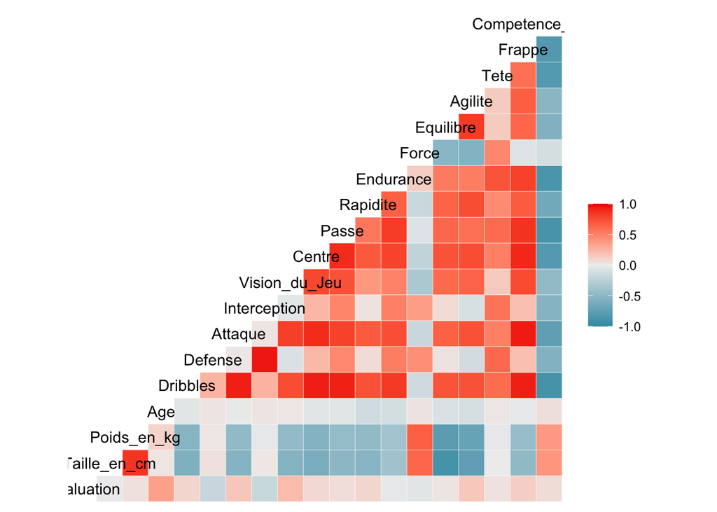

Ce graphe represente la correlation entre les differentes variables de notre jeu de donnees. Premierement, nous pouvons remarquer que plus le carre est bleu (tres proche de -1.0), et moins il y a de relation entre les 2 variables. A l’exemple de Competence_Gardien et Frappe ou Competence_Gardien et Dribbles, ce qui est tout a fait normal car tres peu de gardien de but, voir aucun, ne possede une bonne qualite de frappe ou de dribbles.

Deuxiemement, plus le carre est orange (tres proche de 1.0), et plus il y a de relation entre les 2 variables. A l’exemple de Frappe et Attaque, ce qui est tout aussi normal car la plupart des joueurs offensifs (attaquants) possedent de bonnes capacites face au but.

Pour representer le secteur defensif, nous allons utiliser les variables Defense et Interception :

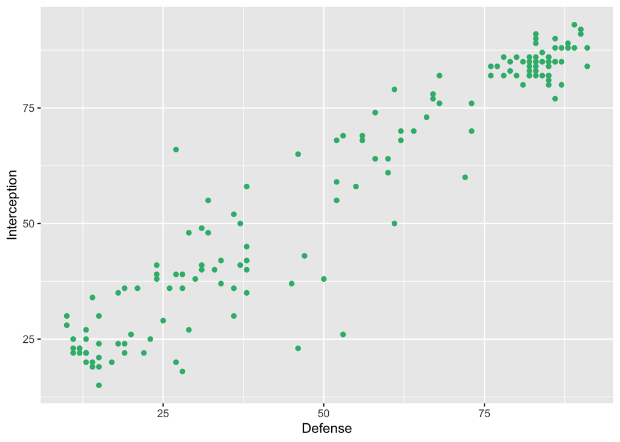

Pour representer le secteur offensif, nous allons utiliser les variables Attaque et Dribbles :

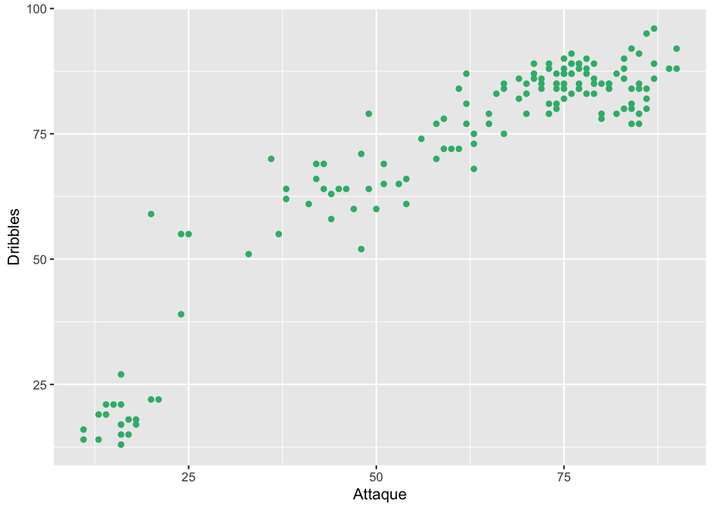

1. La variable “Position”

Les differentes positions presentes dans notre jeu de donnees sont les suivantes :

Gardiens : Nous pouvons constater sur ce graphe qu’il y a 20 gardien.

```
## # A tibble: 20 x 25
##    Nom   Nationalite Club  Position Evaluation Taille_en_cm Poids_en_kg
##    <chr> <fct>       <fct> <fct>         <int>        <int>       <int>
##  1 MANU… GERMANY     FC B… GARDIEN          92          193          92
##  2 DE G… SPAIN       MANC… GARDIEN          90          193          82
##  3 THIB… BELGIUM     CHEL… GARDIEN          89          199          91
##  4 HUGO… FRANCE      SPURS GARDIEN          88          188          82
##  5 PETR… CZECH REPU… ARSE… GARDIEN          88          196          90
##  6 GIAN… ITALY       JUVE… GARDIEN          88          192          91
##  7 JAN … SLOVENIA    ATLE… GARDIEN          87          189          87
##  8 SAMI… SLOVENIA    INTER GARDIEN          87          193          89
##  9 BERN… GERMANY     BAYE… GARDIEN          86          190          83
## 10 KEYL… COSTA RICA  REAL… GARDIEN          85          185          78
## 11 STEP… FRANCE      AS S… GARDIEN          85          188          93
## 12 DANI… CROATIA     AS M… GARDIEN          84          191          84
## 13 RALF… GERMANY     FC S… GARDIEN          84          196          95
## 14 SERG… SPAIN       VILL… GARDIEN          84          189          87
## 15 STEV… FRANCE      CRYS… GARDIEN          84          185          82
## 16 GERO… ARGENTINA   REAL… GARDIEN          83          189          80
## 17 TIMO… GERMANY     1. F… GARDIEN          83          192          90
## 18 ANTH… PORTUGAL    OLYM… GARDIEN          83          184          81
## 19 MATT… ITALY       GENOA GARDIEN          83          188          74
## 20 MARC… GERMANY     FC B… GARDIEN          83          187          85
## # … with 18 more variables: Pied_Fort <fct>, Age <int>, Pied_Faible <fct>,
## #   Dribbles <int>, Defense <int>, Attaque <int>, Interception <int>,
## #   Vision_du_Jeu <int>, Centre <int>, Passe <int>, Rapidite <int>,
## #   Endurance <int>, Force <int>, Equilibre <int>, Agilite <int>,
## #   Tete <int>, Frappe <int>, Competence_Gardien <int>
```

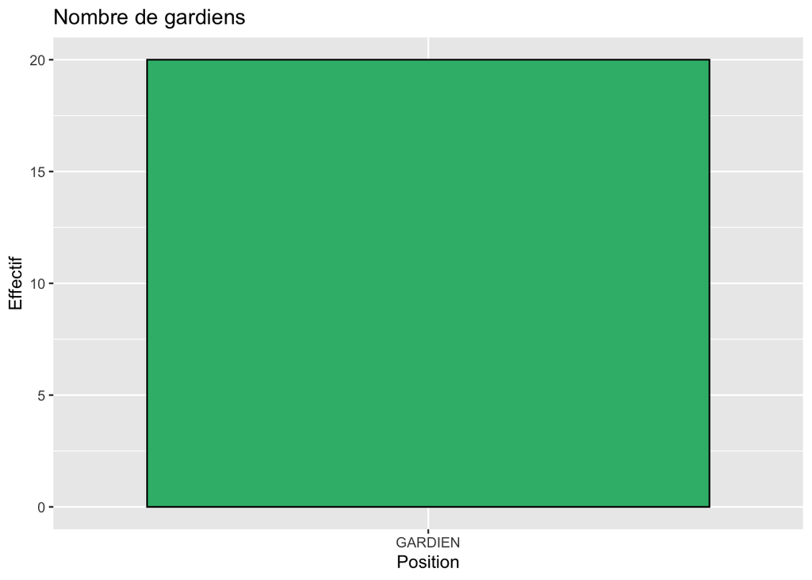

Defenseurs (Centre, Gauche, Droit) : Nous pouvons constater sur ce graphe qu’il y a 34 “DEFENSEUR CENTRE”, 3 “DEFENSEUR DROIT” et 4 “DEFENSEUR GAUCHE”

```
## # A tibble: 41 x 25
##    Nom   Nationalite Club  Position Evaluation Taille_en_cm Poids_en_kg
##    <chr> <fct>       <fct> <fct>         <int>        <int>       <int>
##  1 JERO… GERMANY     FC B… DEFENSE…         89          192          90
##  2 THIA… BRAZIL      PSG   DEFENSE…         89          183          79
##  3 SERG… SPAIN       REAL… DEFENSE…         89          183          75
##  4 DIEG… URUGUAY     ATLE… DEFENSE…         88          185          73
##  5 MATS… GERMANY     FC B… DEFENSE…         88          191          92
##  6 GIOR… ITALY       JUVE… DEFENSE…         88          187          84
##  7 PHIL… GERMANY     FC B… DEFENSE…         88          170          66
##  8 PEPE  PORTUGAL    REAL… DEFENSE…         88          188          81
##  9 LEON… ITALY       JUVE… DEFENSE…         87          190          85
## 10 PIQUE SPAIN       FC B… DEFENSE…         87          193          85
## # … with 31 more rows, and 18 more variables: Pied_Fort <fct>, Age <int>,
## #   Pied_Faible <fct>, Dribbles <int>, Defense <int>, Attaque <int>,
## #   Interception <int>, Vision_du_Jeu <int>, Centre <int>, Passe <int>,
## #   Rapidite <int>, Endurance <int>, Force <int>, Equilibre <int>,
## #   Agilite <int>, Tete <int>, Frappe <int>, Competence_Gardien <int>
```

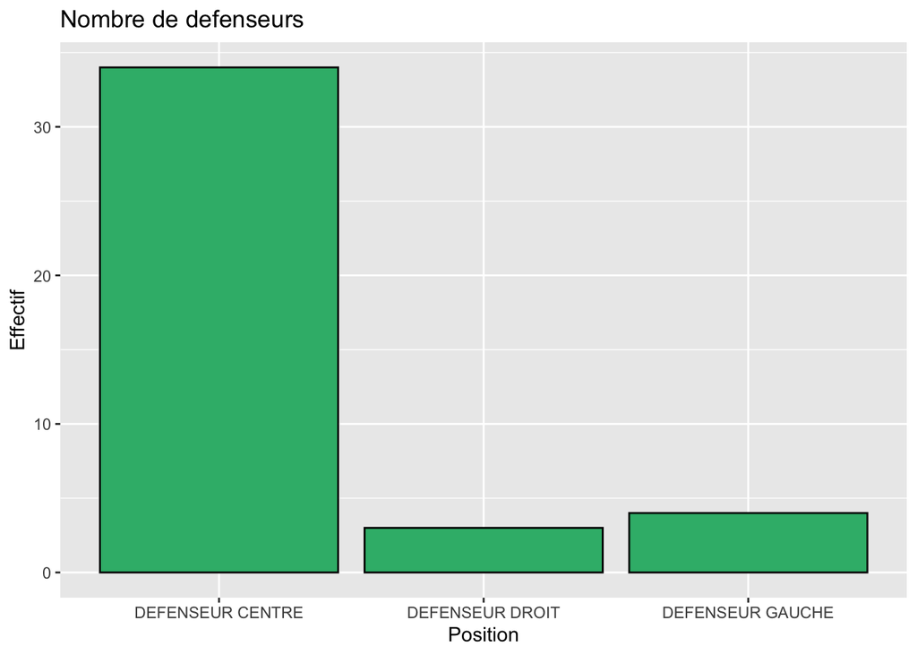

Milieux (Defensif, Central, Gauche, Droit, Offensif) : Nous pouvons constater sur ce graphe que notre jeu de donnees sur les Milieux contient beaucoup plus de poste “MILIEUX CENTRAL”

```
## # A tibble: 51 x 25
##    Nom   Nationalite Club  Position Evaluation Taille_en_cm Poids_en_kg
##    <chr> <fct>       <fct> <fct>         <int>        <int>       <int>
##  1 LUKA… CROATIA     REAL… MILIEUX…         89          174          65
##  2 MESU… GERMANY     ARSE… MILIEUX…         89          180          76
##  3 PAUL… FRANCE      MANC… MILIEUX…         88          191          84
##  4 KEVI… BELGIUM     MANC… MILIEUX…         88          181          68
##  5 TONI… GERMANY     REAL… MILIEUX…         88          182          78
##  6 INIE… SPAIN       FC B… MILIEUX…         88          171          68
##  7 JAME… COLOMBIA    REAL… MILIEUX…         87          180          75
##  8 ARTU… CHILE       FC B… MILIEUX…         87          180          75
##  9 IVAN… CROATIA     FC B… MILIEUX…         87          184          78
## 10 DAVI… SPAIN       MANC… MILIEUX…         87          173          67
## # … with 41 more rows, and 18 more variables: Pied_Fort <fct>, Age <int>,
## #   Pied_Faible <fct>, Dribbles <int>, Defense <int>, Attaque <int>,
## #   Interception <int>, Vision_du_Jeu <int>, Centre <int>, Passe <int>,
## #   Rapidite <int>, Endurance <int>, Force <int>, Equilibre <int>,
## #   Agilite <int>, Tete <int>, Frappe <int>, Competence_Gardien <int>
```

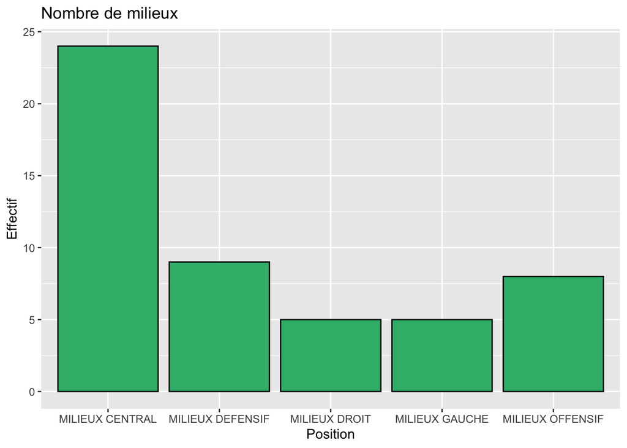

Attaquants (Ailier, Attaquant) : Nous pouvons constater que notre jeu de donnees est compose d’autant d’ailier que d’attaquants normaux.

```
## # A tibble: 38 x 25
##    Nom   Nationalite Club  Position Evaluation Taille_en_cm Poids_en_kg
##    <chr> <fct>       <fct> <fct>         <int>        <int>       <int>
##  1 CRIS… PORTUGAL    REAL… AILIER           94          185          80
##  2 LION… ARGENTINA   FC B… AILIER           93          170          72
##  3 NEYM… BRAZIL      FC B… AILIER           92          174          68
##  4 LUIS… URUGUAY     FC B… ATTAQUA…         92          182          85
##  5 ROBE… POLAND      FC B… ATTAQUA…         90          185          79
##  6 GARE… WALES       REAL… AILIER           90          183          74
##  7 ZLAT… SWEDEN      MANC… ATTAQUA…         90          195          95
##  8 EDEN… BELGIUM     CHEL… AILIER           89          173          74
##  9 GONZ… ARGENTINA   JUVE… ATTAQUA…         89          184          92
## 10 SERG… ARGENTINA   MANC… ATTAQUA…         89          173          70
## # … with 28 more rows, and 18 more variables: Pied_Fort <fct>, Age <int>,
## #   Pied_Faible <fct>, Dribbles <int>, Defense <int>, Attaque <int>,
## #   Interception <int>, Vision_du_Jeu <int>, Centre <int>, Passe <int>,
## #   Rapidite <int>, Endurance <int>, Force <int>, Equilibre <int>,
## #   Agilite <int>, Tete <int>, Frappe <int>, Competence_Gardien <int>
```

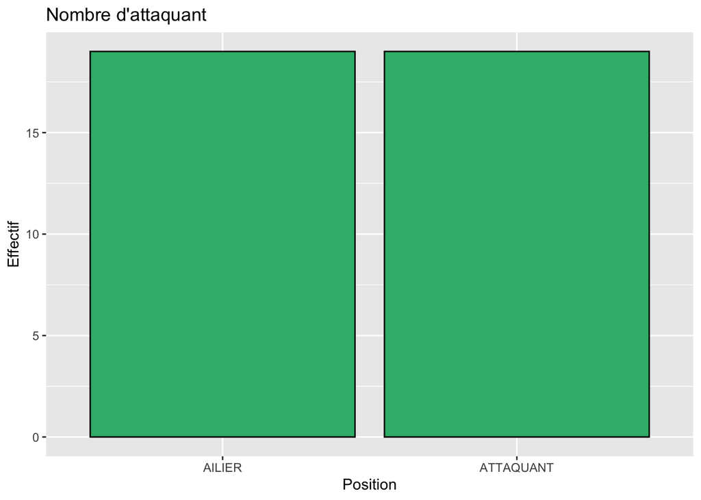

Le joueur se caracterise aussi par sa note globale (Evaluation) qui lui est attribue. Nous allons afficher la repartition des joueurs par evaluation. Par la suite nous allons vous montrer la distribution globale des evaluations de ceux ci par rapport a leur poste respectifs.

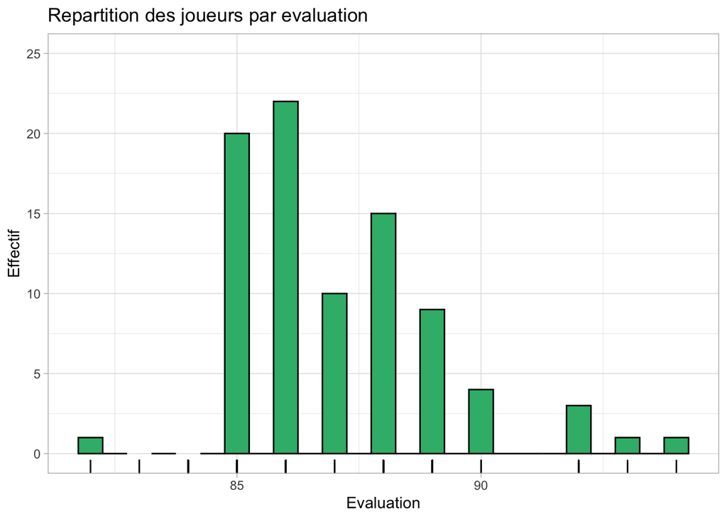

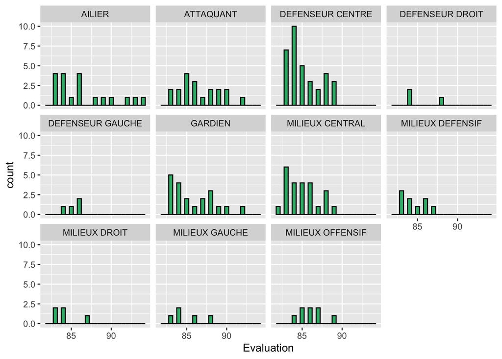

Nous pouvons constater sur le premier graphe que la plus petite evaluation est 82 car grace un simple coup d’oeil nous pouvons deduire que la ligne horizontale situee entre 85 et 90 est 87.5. Par consequent celle situe avant 85 est 82.5. Ce qui nous emmene a penser a juste titre que l’evaluation la plus petite est 82 et est possede par 1 seul joueur. Et la plus grande, 94, possede par 1 seul joueur.

Sur le second graphe nous pouvons observer le nombre de joueurs par poste (detaille) et d’un simple coup d’oeil, en deduire que le poste le represente est “DEFENSEUR CENTRE” suivi par “MILIEUX CENTRAL” et ainsi de suite.

2. La variable “Age”

Notre jeu de donnees contient des joueurs ages de 22 a 39 ans. Le graphe suivant nous montre la repartition globale des joueurs selon leur age.

[figure not shown]

Ce graphe nous demontre que notre jeu de donnees contient par exemple 5 joueurs de 22 ans ou encore 20 joueurs de 29 ans.

Le graphe suivant nous presente la repartition et la moyenne d’age de notre jeu de donnee :

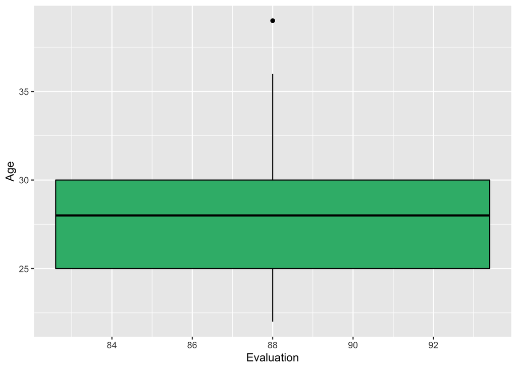

L’age est un attribut assez important pour un sportif et encore plus pour un joueur de football. Les joueurs sont repatis comme suit selon leur age :

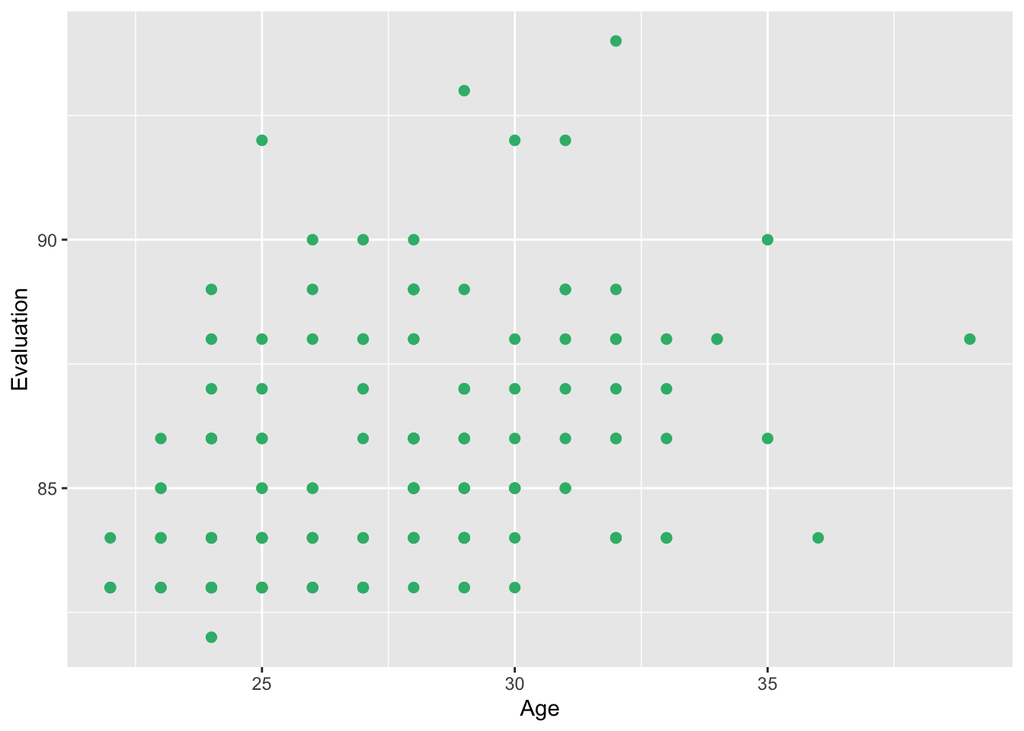

Pour les gardiens :

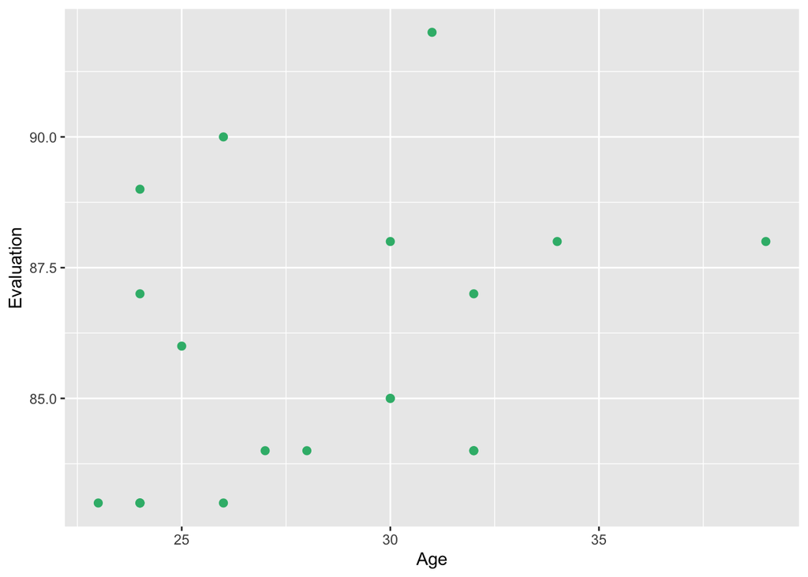

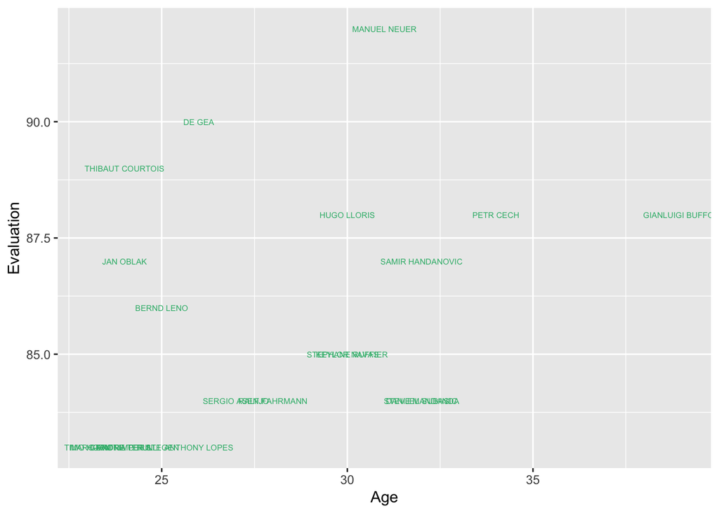

Pour les defenseurs :

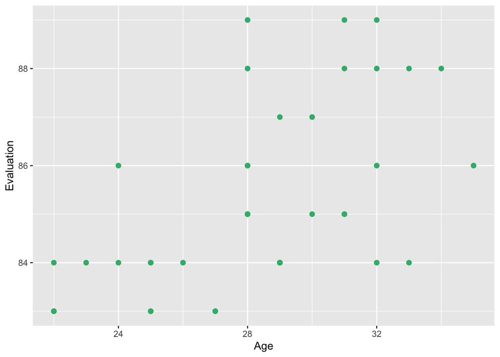

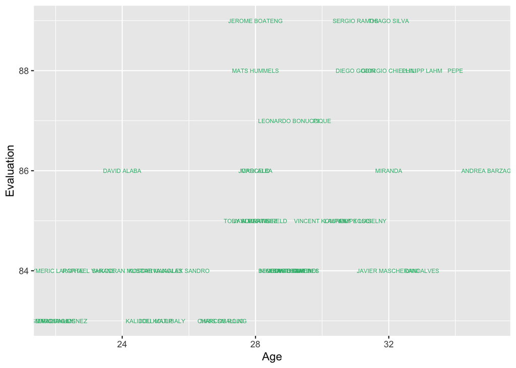

Pour les milieux :

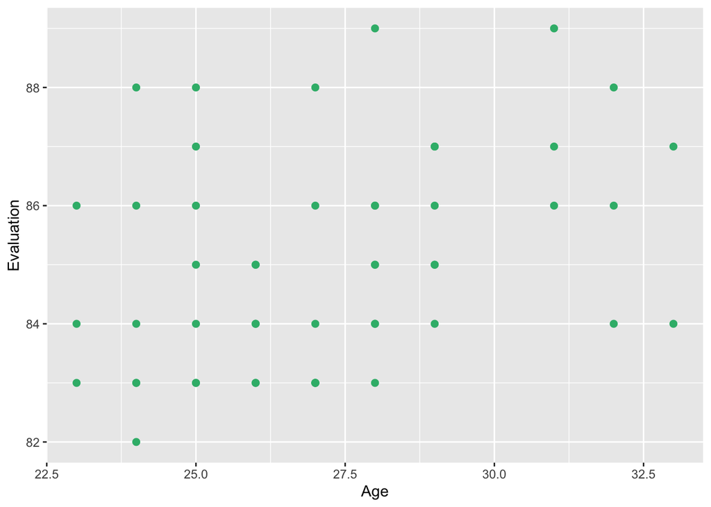

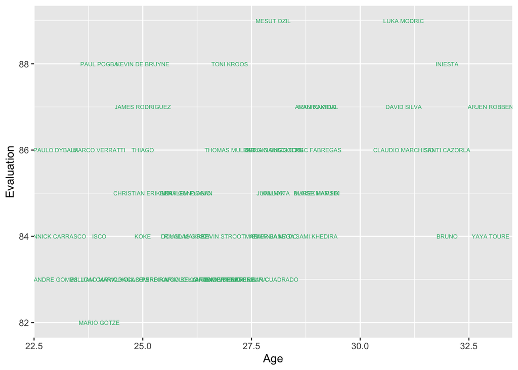

Pour les attaquants :

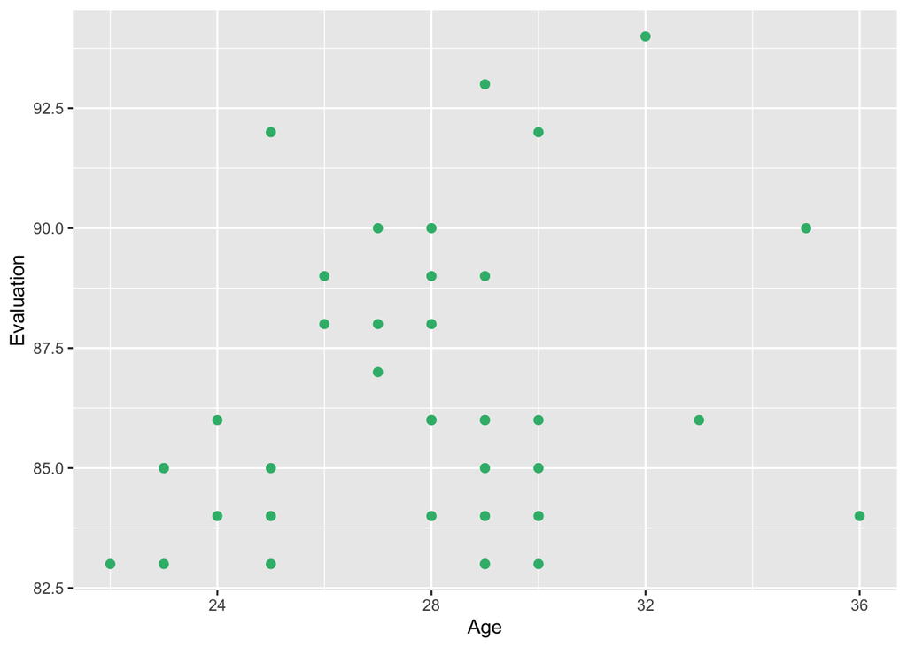

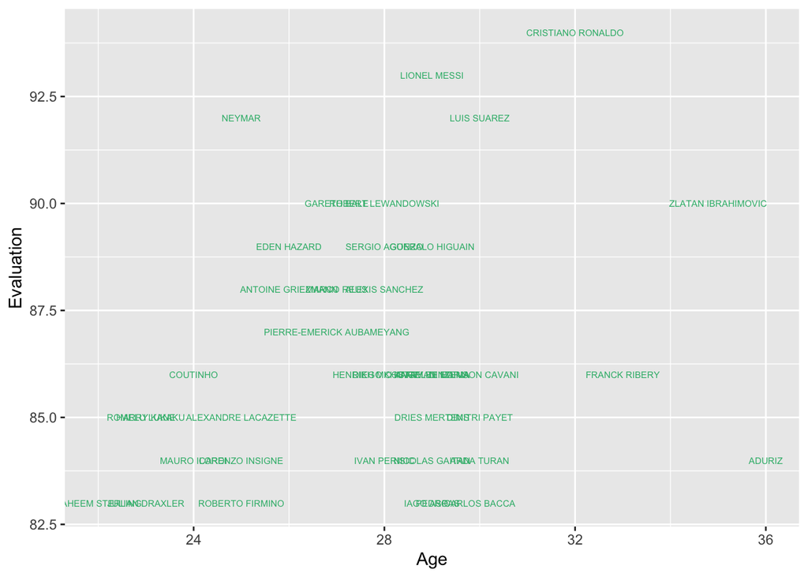

Sachant que notre jeu de donnees contient les 150 meilleurs joueurs de football, ces graphes nous demontrent que la plupart des joueurs de football ont de forte chance d’atteindre leur meilleur niveau entre 25 et 30 ans.

3. La variable “Pied_Fort”

La variable Pied_Fort represente le pied fort du joueur a savoir le droit ou le gauche.

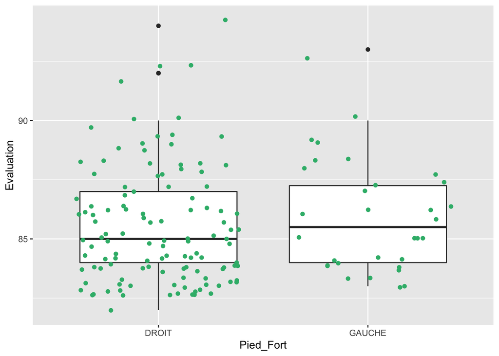

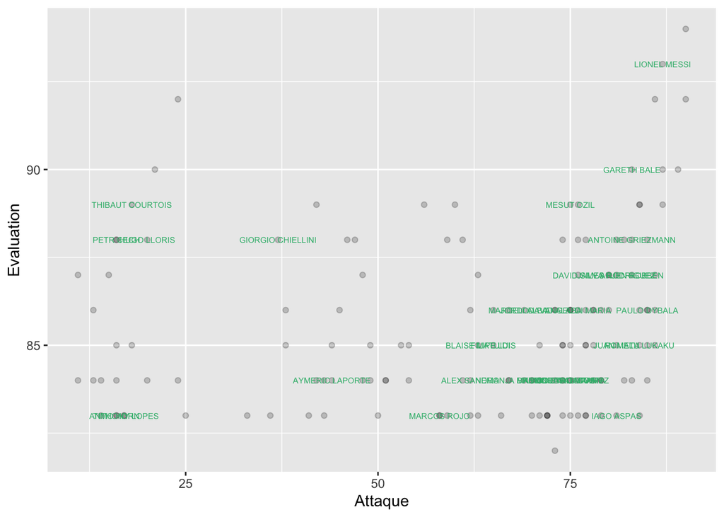

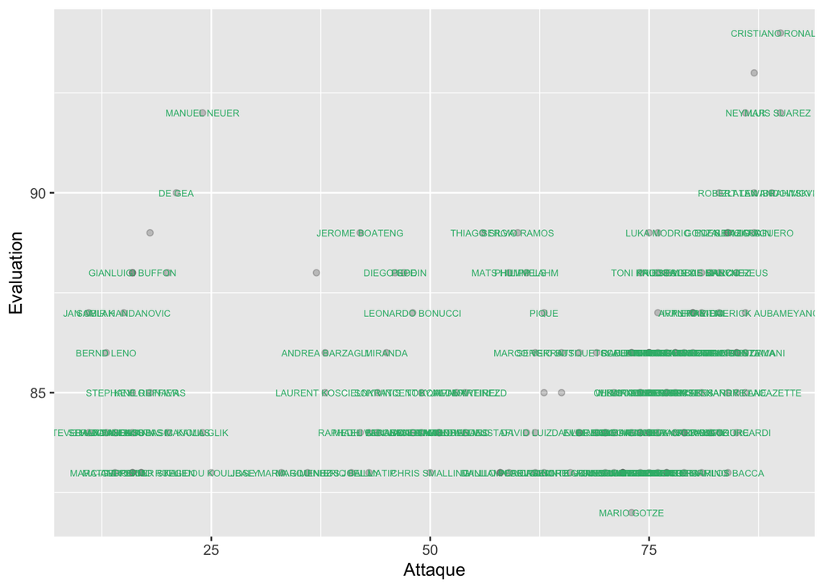

Dans le domaine du football cette variable est tres importante pour determiner le positionnement d’un joueur :

```
## # A tibble: 5 x 3
##   Nom              Position Pied_Fort
##   <chr>            <fct>    <fct>
## 1 THIBAUT COURTOIS GARDIEN  GAUCHE
## 2 HUGO LLORIS      GARDIEN  GAUCHE
## 3 PETR CECH        GARDIEN  GAUCHE
## 4 TIMO HORN        GARDIEN  GAUCHE
## 5 ANTHONY LOPES    GARDIEN  GAUCHE
```

```
## # A tibble: 15 x 3
##    Nom                   Position Pied_Fort
##    <chr>                 <fct>    <fct>
##  1 MANUEL NEUER          GARDIEN  DROIT
##  2 DE GEA                GARDIEN  DROIT
##  3 GIANLUIGI BUFFON      GARDIEN  DROIT
##  4 JAN OBLAK             GARDIEN  DROIT
##  5 SAMIR HANDANOVIC      GARDIEN  DROIT
##  6 BERND LENO            GARDIEN  DROIT
##  7 KEYLOR NAVAS          GARDIEN  DROIT
##  8 STEPHANE RUFFIER      GARDIEN  DROIT
##  9 DANIJEL SUBASIC       GARDIEN  DROIT
## 10 RALF FAHRMANN         GARDIEN  DROIT
## 11 SERGIO ASENJO         GARDIEN  DROIT
## 12 STEVE MANDANDA        GARDIEN  DROIT
## 13 GERONIMO RULLI        GARDIEN  DROIT
## 14 MATTIA PERIN          GARDIEN  DROIT
## 15 MARC-ANDRE TER STEGEN GARDIEN  DROIT
```

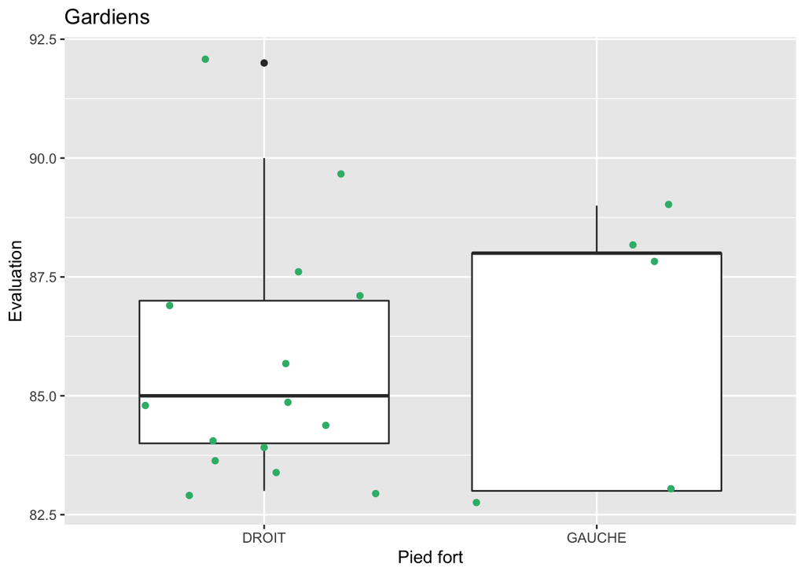

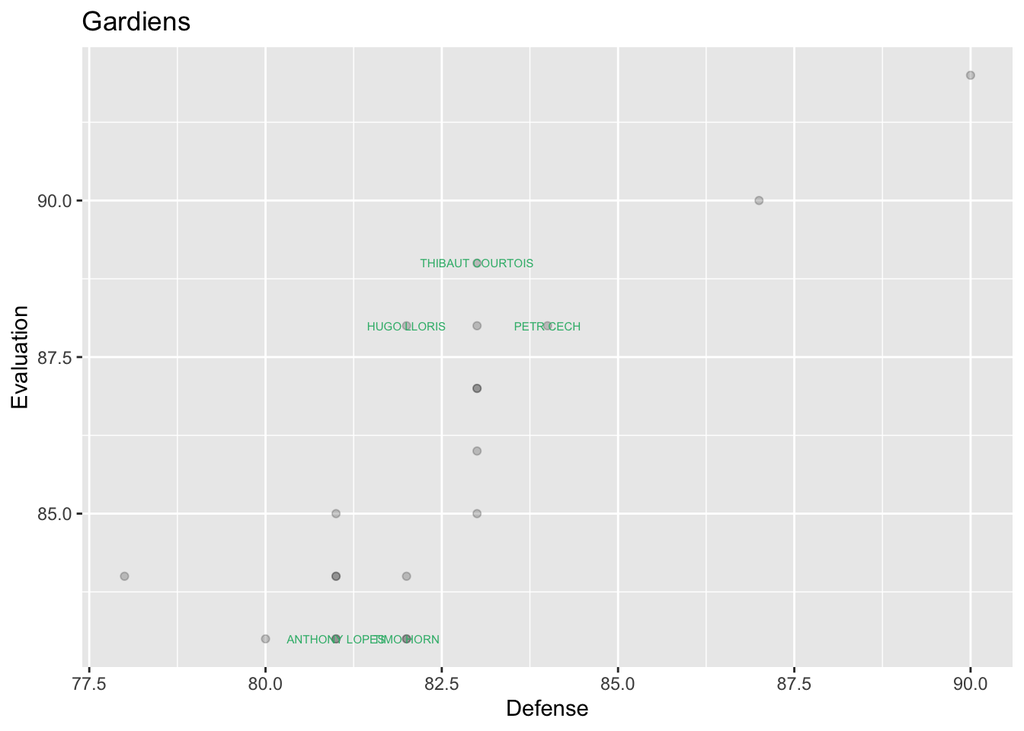

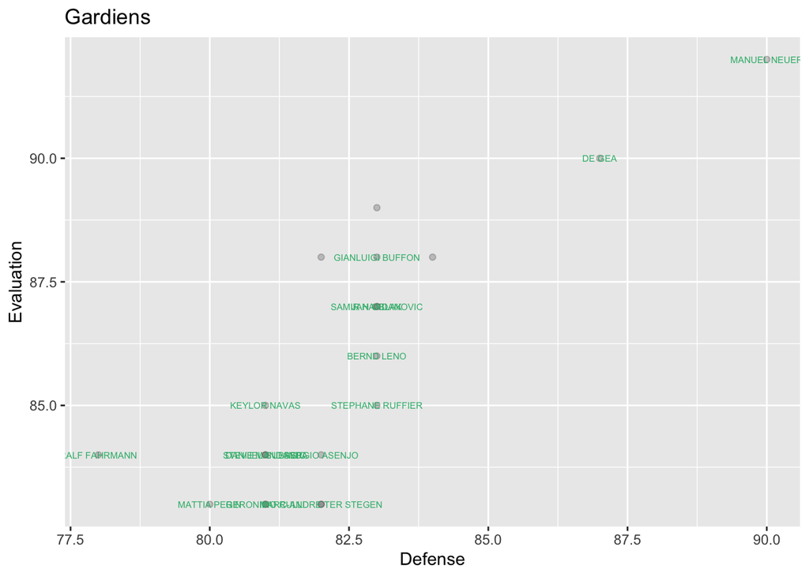

Concernant les gardiens nous pouvons constater qu’il y a 5 gauchers et 15 droitiers. Nous n’allons pas parler des differents postes car il y a qu’une seule variante dans la zone du gardien.

```
## # A tibble: 8 x 3
##   Nom               Position         Pied_Fort
##   <chr>             <fct>            <fct>
## 1 GIORGIO CHIELLINI DEFENSEUR CENTRE GAUCHE
## 2 DAVID ALABA       DEFENSEUR GAUCHE GAUCHE
## 3 JORDI ALBA        DEFENSEUR CENTRE GAUCHE
## 4 MARCELO           DEFENSEUR GAUCHE GAUCHE
## 5 FILIPE LUIS       DEFENSEUR GAUCHE GAUCHE
## 6 AYMERIC LAPORTE   DEFENSEUR CENTRE GAUCHE
## 7 ALEX SANDRO       DEFENSEUR GAUCHE GAUCHE
## 8 MARCOS ROJO       DEFENSEUR CENTRE GAUCHE
```

```
## # A tibble: 33 x 3
##    Nom              Position         Pied_Fort
##    <chr>            <fct>            <fct>
##  1 JEROME BOATENG   DEFENSEUR CENTRE DROIT
##  2 THIAGO SILVA     DEFENSEUR CENTRE DROIT
##  3 SERGIO RAMOS     DEFENSEUR CENTRE DROIT
##  4 DIEGO GODIN      DEFENSEUR CENTRE DROIT
##  5 MATS HUMMELS     DEFENSEUR CENTRE DROIT
##  6 PHILIPP LAHM     DEFENSEUR DROIT  DROIT
##  7 PEPE             DEFENSEUR CENTRE DROIT
##  8 LEONARDO BONUCCI DEFENSEUR CENTRE DROIT
##  9 PIQUE            DEFENSEUR CENTRE DROIT
## 10 MIRANDA          DEFENSEUR CENTRE DROIT
## # … with 23 more rows
```

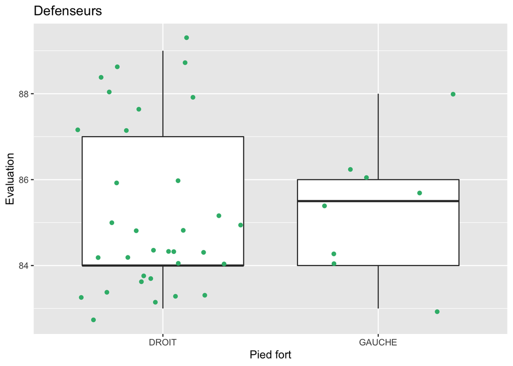

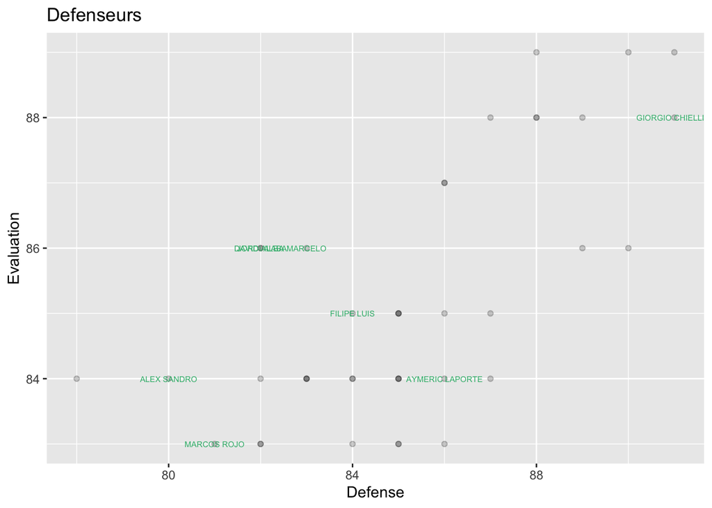

Concernant les defenseurs nous pouvons constater qu’il y a 8 gauchers et 33 droitiers. Nous pouvons constater qu’un defenseur gaucher ne peut se positionner qu’au centre et a gauche, rarement a droite. Et vice versa pour les droitiers.

```
## # A tibble: 12 x 3
##    Nom             Position         Pied_Fort
##    <chr>           <fct>            <fct>
##  1 MESUT OZIL      MILIEUX OFFENSIF GAUCHE
##  2 JAMES RODRIGUEZ MILIEUX OFFENSIF GAUCHE
##  3 DAVID SILVA     MILIEUX CENTRAL  GAUCHE
##  4 ARJEN ROBBEN    MILIEUX DROIT    GAUCHE
##  5 PAULO DYBALA    MILIEUX OFFENSIF GAUCHE
##  6 JUAN MATA       MILIEUX CENTRAL  GAUCHE
##  7 BLAISE MATUIDI  MILIEUX CENTRAL  GAUCHE
##  8 RIYAD MAHREZ    MILIEUX DROIT    GAUCHE
##  9 NEMANJA MATIC   MILIEUX CENTRAL  GAUCHE
## 10 DOUGLAS COSTA   MILIEUX GAUCHE   GAUCHE
## 11 KEVIN STROOTMAN MILIEUX CENTRAL  GAUCHE
## 12 BRUNO           MILIEUX CENTRAL  GAUCHE
```

```
## # A tibble: 39 x 3
##    Nom             Position         Pied_Fort
##    <chr>           <fct>            <fct>
##  1 LUKA MODRIC     MILIEUX CENTRAL  DROIT
##  2 PAUL POGBA      MILIEUX CENTRAL  DROIT
##  3 KEVIN DE BRUYNE MILIEUX CENTRAL  DROIT
##  4 TONI KROOS      MILIEUX CENTRAL  DROIT
##  5 INIESTA         MILIEUX GAUCHE   DROIT
##  6 ARTURO VIDAL    MILIEUX DEFENSIF DROIT
##  7 IVAN RAKITIC    MILIEUX OFFENSIF DROIT
##  8 MARCO VERRATTI  MILIEUX CENTRAL  DROIT
##  9 THOMAS MULLER   MILIEUX OFFENSIF DROIT
## 10 SERGIO BUSQUETS MILIEUX DEFENSIF DROIT
## # … with 29 more rows
```

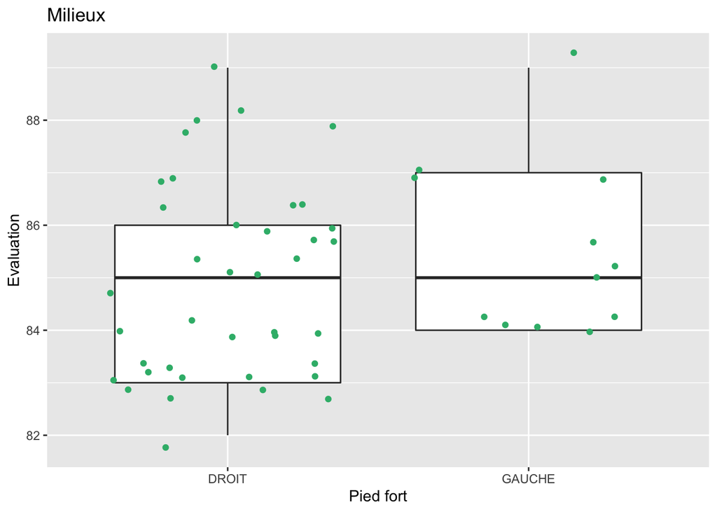

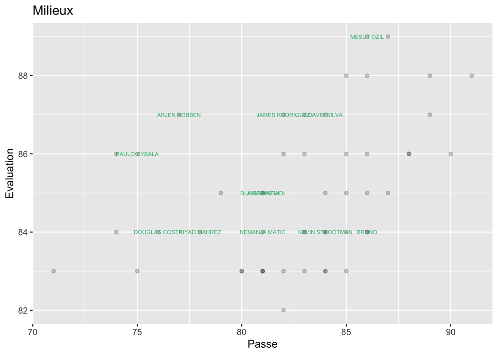

Concernant les milieux, nous avons 12 gauchers et 39 droitiers. Nous pouvons constater que lorsqu’un milieux de terrain est gaucher, il peut se positionner a gauche, au centre ou a droite selon sa capacite a etre efficace et influent sur l’un des deux cotes. Il est est de meme pour les droitier. En d’autre terme le pied fort n’influence pas grandement le positionnement d’un milieux de terrain.

```
## # A tibble: 7 x 3
##   Nom               Position  Pied_Fort
##   <chr>             <fct>     <fct>
## 1 LIONEL MESSI      AILIER    GAUCHE
## 2 GARETH BALE       AILIER    GAUCHE
## 3 ANTOINE GRIEZMANN ATTAQUANT GAUCHE
## 4 ANGEL DI MARIA    AILIER    GAUCHE
## 5 ROMELU LUKAKU     ATTAQUANT GAUCHE
## 6 NICOLAS GAITAN    AILIER    GAUCHE
## 7 IAGO ASPAS        AILIER    GAUCHE
```

```
## # A tibble: 31 x 3
##    Nom                Position  Pied_Fort
##    <chr>              <fct>     <fct>
##  1 CRISTIANO RONALDO  AILIER    DROIT
##  2 NEYMAR             AILIER    DROIT
##  3 LUIS SUAREZ        ATTAQUANT DROIT
##  4 ROBERT LEWANDOWSKI ATTAQUANT DROIT
##  5 ZLATAN IBRAHIMOVIC ATTAQUANT DROIT
##  6 EDEN HAZARD        AILIER    DROIT
##  7 GONZALO HIGUAIN    ATTAQUANT DROIT
##  8 SERGIO AGUERO      ATTAQUANT DROIT
##  9 MARCO REUS         AILIER    DROIT
## 10 ALEXIS SANCHEZ     ATTAQUANT DROIT
## # … with 21 more rows
```

[figure not shown]

[figure not shown]

Concernant les attaquants, nous avons 7 gauchers et 31 droitiers. Nous pouvons constater que le pied fort n’influence pas grandement le positionnement de l’attaquant. Tou comme pour le milieux, sa position dependra de sa preference ou sa capacite a etre efficace et influent sur le terrain.